# `admixr` - overview

Martin Petr

2018-08-24

## Introduction

[ADMIXTOOLS](http://www.genetics.org/content/192/3/1065) is a widely used software package for calculating statistics and testing hypotheses about population admixture. However, although powerful and comprehensive, it is not exactly user-friendly.

A typical ADMIXTOOLS workflow usually involves a combination of `sed`/`awk`/shell scripting and manual editing to create different configuration files. These are then passed as command-line arguments to one of ADMIXTOOLS’ commands, controlling how to run a particular analysis. The result of each analysis is then redirected to another file, and the user needs to extract values of interest from this file (which is full of redundant information), most likely using more shell scripting or (worse) by manual copy-pasting. The results are then analyse in R, Excel or another program.

This workflow very cumbersome, especially if one wants to explore many hypotheses involving different combinations of populations. Most importantly, however, it makes it difficult to follow good practices of reproducible science.

This R package makes it possible to perform all stages of ADMIXTOOLS analysis entirely from within R. It provides a set of convenient functions that completely abstract away the need for “low level” configuration of individual ADMIXTOOLS programs, allowing the user to focus on the analysis itself.

## Installation

To install `admixr` from Github you need to install the package `devtools` first. You can simply run:

```r
install.packages("devtools")
devtools::install_github("bodkan/admixr")
```

Furthermore, if you want to follow the examples in this vignette, you will need the tidyverse meta-package, which you can install with:

```r
install.packages("tidyverse")
```

When everything is ready, you can load both packages:

```r
library(admixr)
library(tidyverse)
```

## A boring technical note about EIGENSTRAT files and ADMIXTOOLS

If you have an EIGENSTRAT “triplet” of files ready and want to know how to calculate different statistics, feel free to skip this section.

### EIGENSTRAT file format

ADMIXTOOLS softwre uses a peculiar set of genetic file formats, which feel strange if you are used to working with [VCF files](http://samtools.github.io/hts-specs/VCFv4.3.pdf). However, the basic idea remains the same - we want to store and access SNP data (REF/ALT alleles) of a set of individuals at a defined set of genomic positions.

EIGENSTRAT datasets always contain three kinds of files:

- `ind` file - specifies name, sex and population assignment of each sample
- `snp` file - specifies positions of SNPs, REF/ALT alleles etc.
- `geno` file - specifies SNP data in a dense string-based format:
  - 0: homozygous ALT
  - 1: heterozygote
  - 2: homozygous REF
  - 9: missing site

As you can see, VCF files are essentially a combination of all three files in a single file. Luckily for us, all three EIGENSTRAT files usually share a common path and prefix (at least you should try to make it so whenever you work with them). This allows us to work with just the prefix, instead of worrying about individual files.

As such, all main `admixr` functions accept an argument called `prefix`, which specifies the path to and prefix of all three EIGENSTRAT files (you can still work with individual files if you need to, using `ind`, `snp` and `geno` arguments of each `admixr` function, but try to avoid that).

Here is a prefix of a small testing SNP dataset that’s distributed with `admixr`. We will be working with this data in the rest of this vignette.

```r
(eigen <- file.path(system.file(package = "admixr", "extdata"), "snps"))
```

```
#> [1] "/Users/martin_petr/projects/admixr/inst/extdata/snps"
```

We can verify that there are three files with this prefix:

```r
dir(path = dirname(eigen))
```

```
#> [1] "snps.geno" "snps.ind"  "snps.snp"
```

Let’s look at their contents. Here are three lines from each of them:

**`ind` file**

```
#> Chimp    U   Chimp
#> Mbuti    U   Mbuti
#> Yoruba   U   Yoruba
```

**`snp` file**

```
#> 1_832756 1   0.008328    832756  T   G
#> 1_838931 1   0.008389    838931  A   C
#> 1_843249 1   0.008432    843249  A   T
```

**`geno` file**

```
#> 902021012000
#> 922221211222
#> 922222122222
```

## Philosophy of `admixr`

The goal of this package is to make it easier to run ADMIXTOOLS analyses, without having to worry about (in ADMIXTOOLS jargon) par/pop/log/left/right files and other low level detail.

The only interface between you and ADMIXTOOLS are the following R functions:

- `d()`
- `f4()`
- `f4ratio()`
- `f3()`
- `qpAdm()`

Anything that would often take [dozens of lines of shell scripts](https://gaworkshop.readthedocs.io/en/latest/contents/06_f3/f3.html) can be accomplished by running a single line of R code.

The only thing that is needed is:

- triplet of files in an EIGENSTRAT format
- working ADMIXTOOLS installation
- R :)

## $D$ statistic

Next question we could ask is - how closely related are different African populations to non-Africans today? One way to look at this is using the following D statistic: $D(\textrm{non-African}, \textrm{Denisova}, \textrm{African Y}, \textrm{Chimp})$. This statistic is simply based on counting sites that match an African $Y$, and is informative about the “branching” order of non-Africans from non-Africans over time. The more positive this $D$ statistic is, the more recently did non-Africans split from an African population $Y4.

```r
# place sample names into variables for more readable code
nonafr <- c("French", "Sardinian", "Han", "Papuan")
afr <- c("Khomani_San", "Mbuti", "Yoruba", "Dinka")
```

We can calculate $D$ statistic using `admixr`’s function `d`:

```r
df <- d(W = nonafr, X = "Denisova", Y =  afr, Z = "Chimp", prefix = eigen)
```

```r
head(df)
```

[output not shown]

We can see that the resulting `data.frame` object contains all the input information, but also additional statistics:

- `D` - $D$ statistic value
- `stderr` - standard error of the $D$ statistic calculated with block jackknife
- `Zscore` - $Z$ significance value
- `BABA`/`ABBA` - counts of observed site patterns
- `nsnps` - number of SNPs used for the calculation in this row

The format of output tables is very similar of other `admixr` functions, and they generally differ only in the name of the output column.

In general, tables are not a good representation of this kind of data, especially as the number of samples increases. This is what the results look like when plotted using the `ggplot2` package:

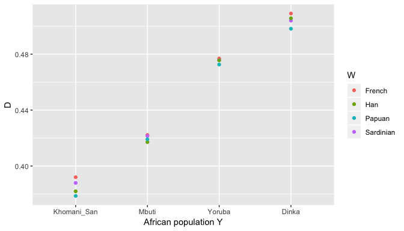

```r
ggplot(df, aes(fct_reorder(Y, D), D, color = W)) +
  geom_point() +
  labs(x = "African population Y")
```

We can see that the closest African population to non-Africans today are East African Dinka, which is consistent with the hypothesis that the ancestors of all non-Africans today split of the East African lineage during the Out of Africa migration. Decreasing values of the $D$ statistic for Yoruba, Mbuti and San fits with what we know about the split times of African from [other](http://science.sciencemag.org/content/early/2017/09/27/science.aao6266) studies, with San being the most divergent modern human population, followed by Mbuti, Yoruba and Dinka.

## $f_4$ statistic

An alternative way of addressing the previous question would be to use the $f_4$ statistic, which is very similar to $D$ statistic. In fact, if $D$ is calculated as

$$D = \frac{\textrm{# BABA sites - # ABBA sites}}{\textrm{# BABA sites + # ABBA sites}},$$

$f_4$ statistic is simply obtained by skipping the normalization step. Therefore,

$$f_4 = \textrm{# BABA sites - # ABBA sites}$$

Sometime one is more convenient than other though, so `admixr` provides a separate function for calculating $f_4$ statistics called `f4`.

To repeat the previous analysis, we can run:

```r
df <- f4(W = nonafr, X = "Denisova", Y =  afr, Z = "Chimp", prefix = eigen)
```

```r
head(df)
```

| W | X | Y | Z | f4 | stderr | Zscore | BABA | ABBA | nsnps |
| --- | --- | --- | --- | --- | --- | --- | --- | --- | --- |
| French | Denisova | Khomani_San | Chimp | 0.039578 | 0.000645 | 61.377 | 34265 | 14966 | 487616 |
| French | Denisova | Mbuti | Chimp | 0.044306 | 0.000634 | 69.886 | 36393 | 14786 | 487683 |
| French | Denisova | Yoruba | Chimp | 0.054419 | 0.000695 | 78.271 | 41087 | 14551 | 487621 |
| French | Denisova | Dinka | Chimp | 0.059352 | 0.000721 | 82.266 | 42904 | 13958 | 487713 |
| Sardinian | Denisova | Khomani_San | Chimp | 0.039454 | 0.000645 | 61.159 | 34408 | 15174 | 487495 |
| Sardinian | Denisova | Mbuti | Chimp | 0.044568 | 0.000644 | 69.168 | 36642 | 14912 | 487561 |

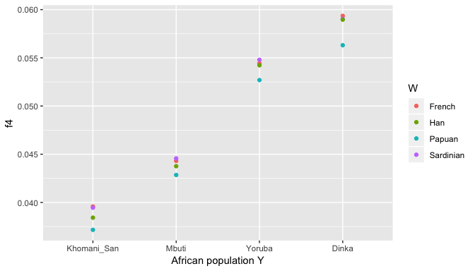

```r
ggplot(df, aes(fct_reorder(Y, f4), f4, color = W)) +
  geom_point() +
  labs(x = "African population Y")
```

As we can see, we can make the same conclusion using $f_4$ statistic, as we made using $D$ statistic. The higher the $f_4$ value, the more drift the samples in $W$ and $Y$ shared. In other words, the more recently the split between the two happened. Again, even this very simple analysis reproduces the major characteristics of modern human demographic history inferred using much more sophisticated methods.

## $f_4$-ratio statistic

```r
df <- f4ratio(
  X = c("French", "Sardinian", "Han", "Papuan", "Dinka", "Mbuti", "Khomani_San"),
  A = "Altai", B = "Vindija", C = "Yoruba", O = "Chimp",
  prefix = eigen
)
```

This is what the final `data.frame` looks like:

```r
df
```

| A | B | X | C | O | alpha | stderr | Zscore |
| --- | --- | --- | --- | --- | --- | --- | --- |
| Altai | Vindija | French | Yoruba | Chimp | 0.023774 | 0.006173 | 3.851 |
| Altai | Vindija | Sardinian | Yoruba | Chimp | 0.024468 | 0.006079 | 4.025 |
| Altai | Vindija | Han | Yoruba | Chimp | 0.022117 | 0.005901 | 3.748 |
| Altai | Vindija | Papuan | Yoruba | Chimp | 0.037311 | 0.005821 | 6.410 |
| Altai | Vindija | Dinka | Yoruba | Chimp | -0.001500 | 0.005407 | -0.277 |
| Altai | Vindija | Mbuti | Yoruba | Chimp | 0.000319 | 0.005721 | 0.056 |

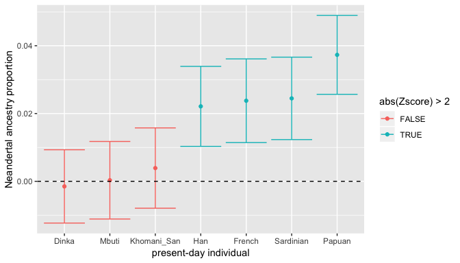

```r
ggplot(df, aes(fct_reorder(X, alpha), alpha, color = abs(Zscore) > 2)) +
  geom_point() +
  geom_errorbar(aes(ymin = alpha - 2 * stderr, ymax = alpha + 2 * stderr)) +
  geom_hline(yintercept = 0, linetype = 2) +
  labs(y = "Neandertal ancestry proportion", x = "present-day individual")
```

Despite the wide confidence intervals (caused by a very low number of SNPs in our testing dataset), we can notice several well-known features:

- No significant Neandertal ancestry in present-day Africans.
- Between 2-3% Neandertal ancestry in present-day non-Africans.
- A much higher proportion of Neandertal ancestry in people from Papua New Guinea.

Again, as you can see, we got a nice “publication-ready” figure in just a few lines of R code! No shell, no `awk/grep` or manual editing and copy-pasting required. 👍